# Assignment3

Mary Geschwindt

9/18/2020

## Assignment Setup

My first step is to load the libraries I’ll need for this assignment:

```r
library(tidyverse)
library(ggplot2)
```

Now I’ll load my csv file from Assignment 1:

```r
women_nyctransport2018 <- read.csv("women_nyctransport2018.csv")
```

As a reminder, my variables include:

1. Means of transportation to work (categorical): JWTR
2. Age (continuous): AGEP
3. Travel time to work (continuous): JWMNP
4. Ambulatory difficulty (categorical): DPHY
5. Race (categorical): RAC1P
6. Income (continuous): PINCP

And my population is women in New York City who commute to work.

## Relationship Between Two Continuous Variables

### Age and Travel Time to Work

```r
correlation1 <- cor.test(women_nyctransport2018$AGEP, women_nyctransport2018$JWMNP)

correlation1
```

```
##
##  Pearson's product-moment correlation
##
## data:  women_nyctransport2018$AGEP and women_nyctransport2018$JWMNP
## t = 2.8435, df = 321, p-value = 0.004749
## alternative hypothesis: true correlation is not equal to 0
## 95 percent confidence interval:
##  0.04844493 0.26140281
## sample estimates:
##       cor
## 0.1567452
```

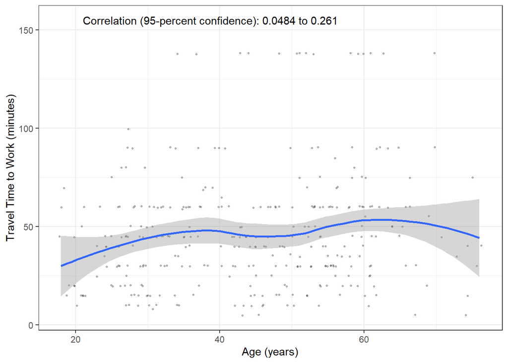

```r
ggplot(women_nyctransport2018, aes(x = AGEP, y = JWMNP)) +
  geom_point(size = 0.5, alpha = 0.25, position = "jitter") +
  geom_smooth() +
  theme_bw() +
  scale_x_continuous(name = "Age (years)") +
  scale_y_continuous(name = "Travel Time to Work (minutes)") +
  annotate(geom = "text", x = 21, y = 155,
           label = paste("Correlation (95-percent confidence):",
                         prettyNum(correlation1$conf.int[1], digits = 3),
                                   "to",
                                   prettyNum(correlation1$conf.int[2], digits = 3)),
                         hjust = 0)
```

There is a weak correlation between age and travel time to work for people in my sample population. The p-value is about 0.005, which is close to 0, meaning that the correlation is weak but a relationship does exist. Additionally, because the 95-percent confidence intervals are positive numbers, the correlation is positive.

### Income and Age

```r
correlation2 <- cor.test(women_nyctransport2018$PINCP, women_nyctransport2018$AGEP)

correlation2
```

```
##
##  Pearson's product-moment correlation
##
## data:  women_nyctransport2018$PINCP and women_nyctransport2018$AGEP
## t = 2.6787, df = 321, p-value = 0.007772
## alternative hypothesis: true correlation is not equal to 0
## 95 percent confidence interval:
##  0.03937323 0.25291468
## sample estimates:
##       cor
## 0.1478669
```

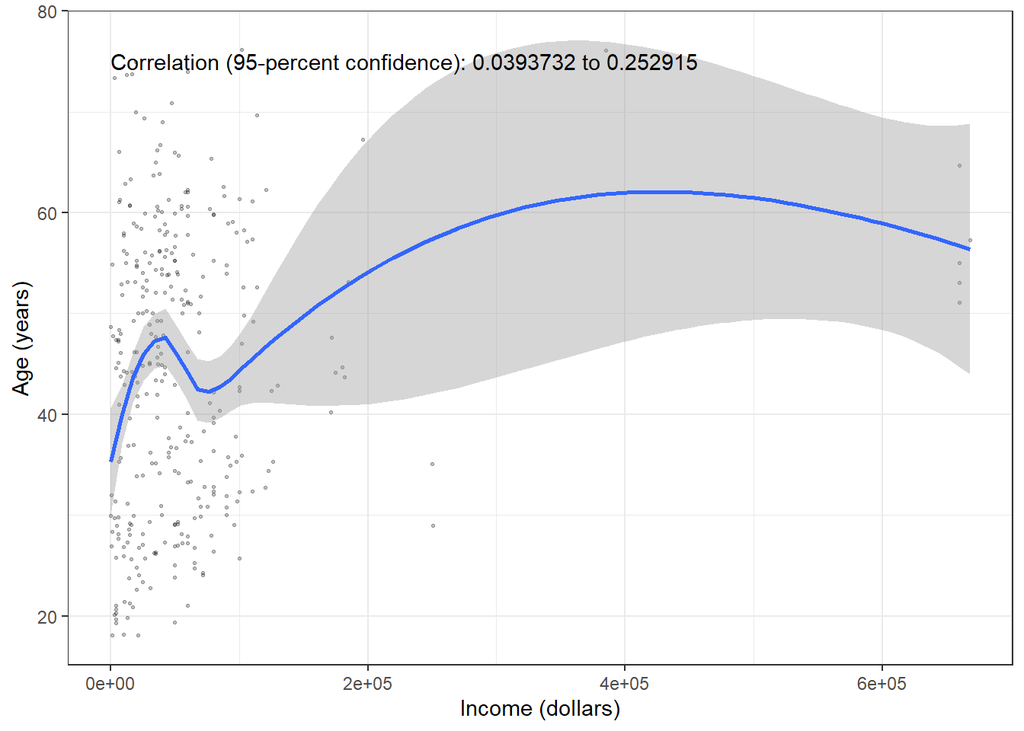

```r
ggplot(women_nyctransport2018, aes(x = PINCP, y = AGEP)) +
  geom_point(size = 0.5, alpha = 0.25, position = "jitter") +
  geom_smooth() +
  theme_bw() +
  scale_x_continuous(name = "Income (dollars)") +
  scale_y_continuous(name = "Age (years)") +
  annotate(geom = "text", x = 16, y = 75,
           label = paste("Correlation (95-percent confidence):",
                         prettyNum(correlation2$conf.int[1], digits = 6),
                                   "to",
                                   prettyNum(correlation2$conf.int[2], digits = 6)),
                         hjust = 0)
```

### Income and Travel Time to Work

```r
correlation3 <- cor.test(women_nyctransport2018$PINCP, women_nyctransport2018$JWMNP)

correlation3
```

```
##
##  Pearson's product-moment correlation
##
## data:  women_nyctransport2018$PINCP and women_nyctransport2018$JWMNP
## t = -0.17565, df = 321, p-value = 0.8607
## alternative hypothesis: true correlation is not equal to 0
## 95 percent confidence interval:
##  -0.1188054  0.0994318
## sample estimates:
##          cor
## -0.009803566
```

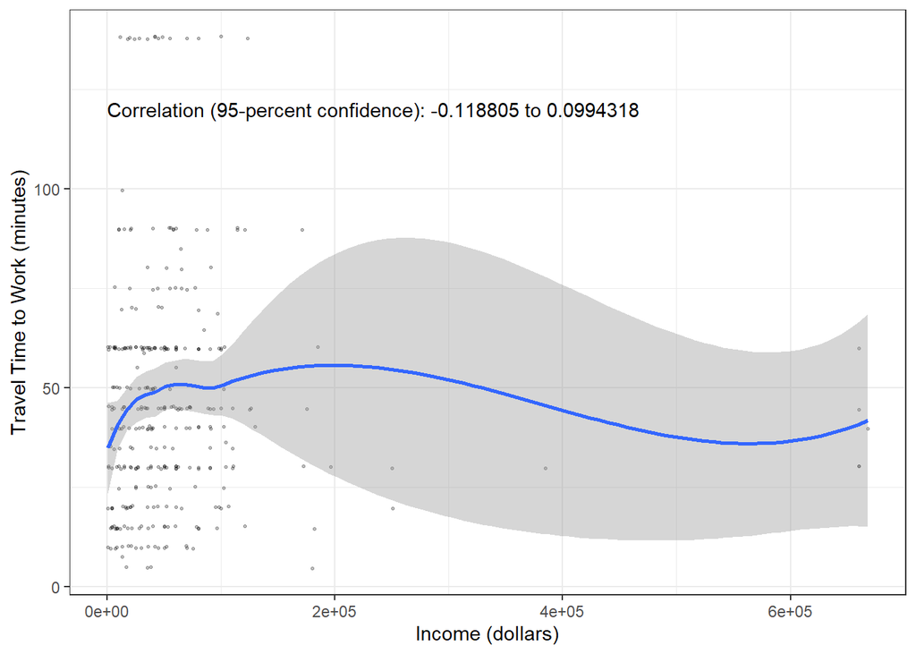

```r
ggplot(women_nyctransport2018, aes(x=PINCP, y=JWMNP)) +
  geom_point(size = 0.5, alpha = 0.25, position = "jitter") +
  geom_smooth() +
  theme_bw() +
  scale_x_continuous(name = "Income (dollars)") +
  scale_y_continuous(name = "Travel Time to Work (minutes)") +
  annotate(geom = "text", x = 16, y = 120,
           label = paste("Correlation (95-percent confidence):",
                         prettyNum(correlation3$conf.int[1], digits = 6),
                                   "to",
                                   prettyNum(correlation3$conf.int[2], digits = 6)),
                         hjust = 0)
```

## Relationship Between a Continous Variable and a Binary Variable

### Age and Ambulatory Difficulty

```r
difference1 = t.test(AGEP ~ DPHY_label, data = women_nyctransport2018)

difference1
```

```
##
##  Welch Two Sample t-test
##
## data:  AGEP by DPHY_label
## t = -1.1413, df = 7.2176, p-value = 0.2902
## alternative hypothesis: true difference in means is not equal to 0
## 95 percent confidence interval:
##  -22.271211   7.711687
## sample estimates:
##  mean in group No mean in group Yes
##          44.09524          51.37500
```

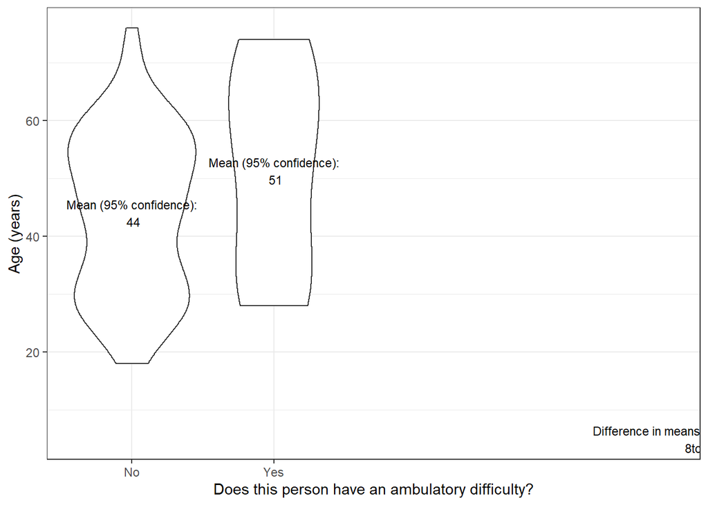

```r
ggplot(women_nyctransport2018, aes(x = DPHY_label, y = AGEP)) +
  geom_violin() +
  theme_bw() +
  scale_x_discrete(name = "Does this person have an ambulatory difficulty?",
                   labels = c("No", "Yes")) +
  scale_y_continuous(name = "Age (years)") +
  annotate(geom = "text", x = 5, y = 5, size = 3,
           label = paste("Difference in means/n(95% confidence):\n",
                         prettyNum(abs(difference1$conf.int[2]),
                                   digits = 0), "to",
                         prettyNum(abs(difference1$conf.int[1]),
                                   digits = 0),
                         sep = "")) +
  annotate(geom = "text", x = 1, y = difference1$estimate[1], size = 3,
           label = paste("Mean (95% confidence):\n",
                         prettyNum((difference1$estimate[1]), digits = 0))) +
  annotate(geom = "text", x = 2, y = difference1$estimate[2], size = 3,
           label = paste("Mean (95% confidence):\n",
                         prettyNum(difference1$estimate[2], digits = 0)))
```

### Travel Time to Work and Ambulatory Difficulty

```r
difference2 = t.test(JWMNP ~ DPHY_label, data = women_nyctransport2018)

difference2
```

```
##
##  Welch Two Sample t-test
##
## data:  JWMNP by DPHY_label
## t = 0.84058, df = 7.6001, p-value = 0.4262
## alternative hypothesis: true difference in means is not equal to 0
## 95 percent confidence interval:
##  -12.33588  26.28509
## sample estimates:
##  mean in group No mean in group Yes
##           46.9746           40.0000
```

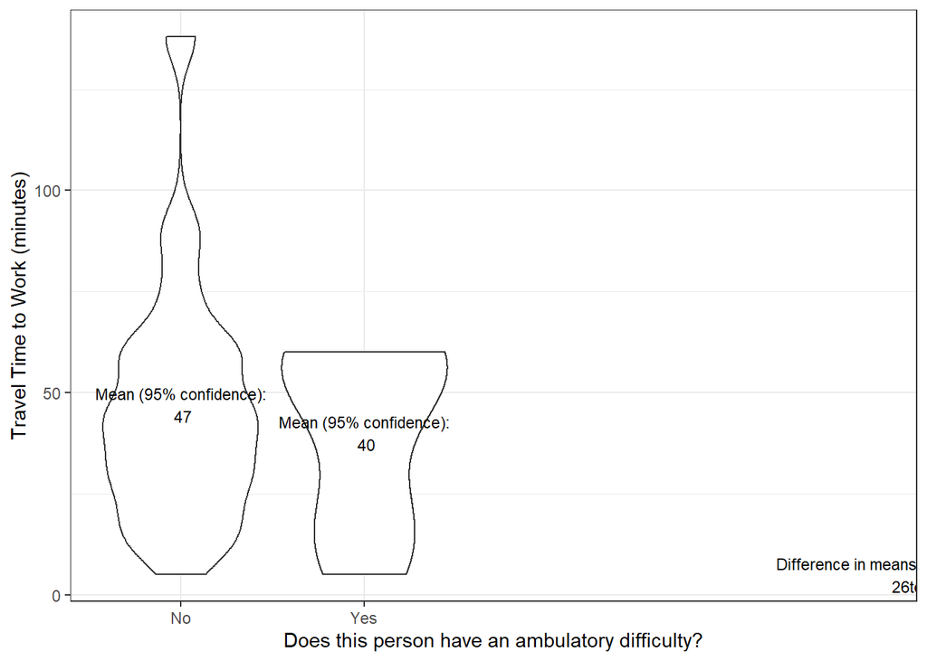

```r
ggplot(women_nyctransport2018, aes(x = DPHY_label, y = JWMNP)) +
  geom_violin() +
  theme_bw() +
  scale_x_discrete(name = "Does this person have an ambulatory difficulty?",
                   labels = c("No", "Yes")) +
  scale_y_continuous(name = "Travel Time to Work (minutes)") +
  annotate(geom = "text", x = 5, y = 5, size = 3,
           label = paste("Difference in means/n(95% confidence):\n",
                         prettyNum(abs(difference2$conf.int[2]),
                                   digits = 0), "to",
                         prettyNum(abs(difference2$conf.int[1]),
                                   digits = 0),
                         sep = "")) +
  annotate(geom = "text", x = 1, y = difference2$estimate[1], size = 3,
           label = paste("Mean (95% confidence):\n",
                         prettyNum((difference2$estimate[1]), digits = 0))) +
  annotate(geom = "text", x = 2, y = difference2$estimate[2], size = 3,
           label = paste("Mean (95% confidence):\n",
                         prettyNum(difference2$estimate[2], digits = 0)))
```

### Income and Ambulatory Difficulty

```r
difference3 = t.test(PINCP ~ DPHY_label, data = women_nyctransport2018)

difference3
```

```
##
##  Welch Two Sample t-test
##
## data:  PINCP by DPHY_label
## t = -0.53233, df = 7.0463, p-value = 0.6109
## alternative hypothesis: true difference in means is not equal to 0
## 95 percent confidence interval:
##  -232094.4  146704.5
## sample estimates:
##  mean in group No mean in group Yes
##          58292.55         100987.50
```

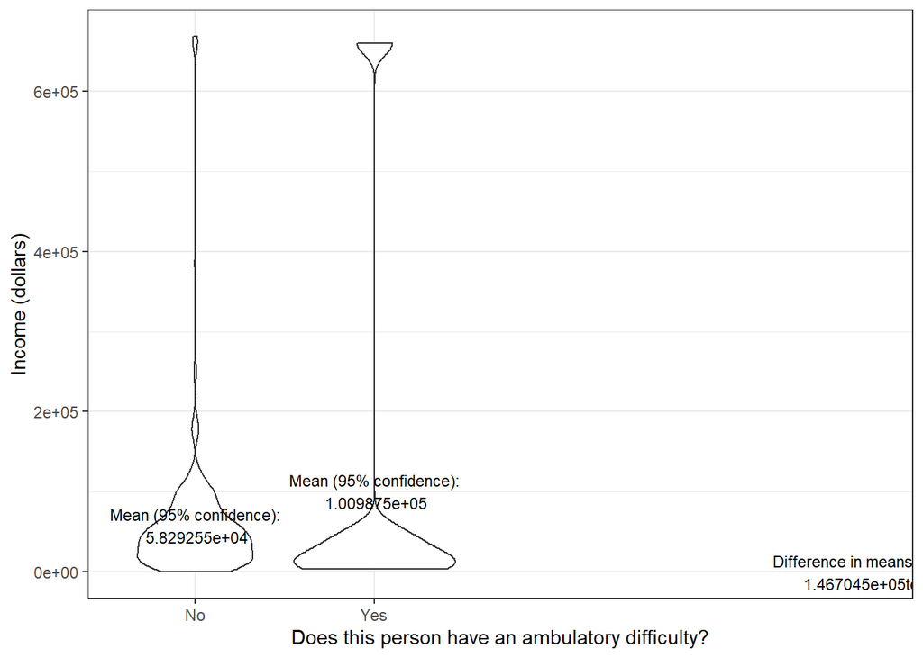

```r
ggplot(women_nyctransport2018, aes(x = DPHY_label, y = PINCP)) +
  geom_violin() +
  theme_bw() +
  scale_x_discrete(name = "Does this person have an ambulatory difficulty?",
                   labels = c("No", "Yes")) +
  scale_y_continuous(name = "Income (dollars)") +
  annotate(geom = "text", x = 5, y = 5, size = 3,
           label = paste("Difference in means/n(95% confidence):\n",
                         prettyNum(abs(difference3$conf.int[2]),
                                   digits = 0), "to",
                         prettyNum(abs(difference3$conf.int[1]),
                                   digits = 0),
                         sep = "")) +
  annotate(geom = "text", x = 1, y = difference3$estimate[1], size = 3,
           label = paste("Mean (95% confidence):\n",
                         prettyNum((difference3$estimate[1]), digits = 0))) +
  annotate(geom = "text", x = 2, y = difference3$estimate[2], size = 3,
           label = paste("Mean (95% confidence):\n",
                         prettyNum(difference3$estimate[2], digits = 0)))
```

## Relationship Between Continuous Variable and a Categorical Variable (three or more levels)

### Age and Means of Transportation

```r
anova1 <- aov(AGEP ~ JWTR_label, data = women_nyctransport2018)

summary(anova1)
```

```
##              Df Sum Sq Mean Sq F value Pr(>F)
## JWTR_label    8   3211   401.3   2.079 0.0375 *
## Residuals   314  60600   193.0
## ---
## Signif. codes:  0 '***' 0.001 '**' 0.01 '*' 0.05 '.' 0.1 ' ' 1
```

```r
differences1 <- TukeyHSD(anova1)

as_tibble(cbind(pair = row.names(differences1$JWTR_label),
                differences1$JWTR_label))
```

```
## # A tibble: 36 x 5
##    pair                     diff         lwr           upr         `p adj`
##    <chr>                    <chr>        <chr>         <chr>       <chr>
##  1 Bus or trolley bus-Bicy~ 19.17117117~ 0.0734554971~ 38.2688868~ 0.0482840646~
##  2 Car, truck, or van-Bicy~ 14.88888888~ -3.470793944~ 33.2485717~ 0.2202866418~
##  3 Ferryboat-Bicycle        22.08333333~ -5.926986117~ 50.0936527~ 0.2545107559~
##  4 Other method-Bicycle     21.13333333~ -5.142675424~ 47.4093420~ 0.2300774494~
##  5 Railroad-Bicycle         22.33333333~ -1.808525921~ 46.4751925~ 0.0951705639~
##  6 Subway or elevated-Bicy~ 13.44517543~ -4.616365800~ 31.5067166~ 0.3301916718~
##  7 Taxicab-Bicycle          16.33333333~ -14.35043427~ 47.0171009~ 0.7687018970~
##  8 Walked-Bicycle           12.86904761~ -6.652241805~ 32.3903370~ 0.5033305941~
##  9 Car, truck, or van-Bus ~ -4.28228228~ -12.89264238~ 4.32807782~ 0.8289373496~
## 10 Ferryboat-Bus or trolle~ 2.912162162~ -19.92724113~ 25.7515654~ 0.9999822487~
## # ... with 26 more rows
```

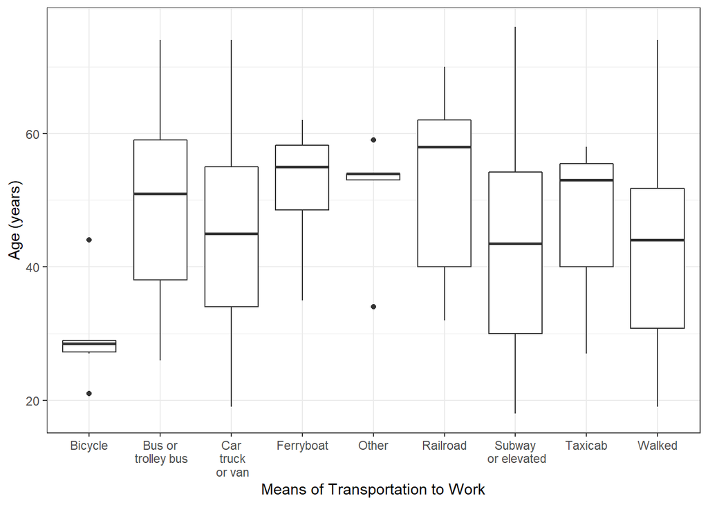

```r
ggplot(women_nyctransport2018, aes(x = JWTR_label, y = AGEP)) +
  geom_boxplot() +
  theme_bw() +
  scale_x_discrete(name = "Means of Transportation to Work",
                  labels = c("Bicycle",
                                  "Bus or\n trolley bus",
                                  "Car\n truck\n or van",
                                  "Ferryboat",
                                  "Other",
                                  "Railroad",
                                  "Subway\n or elevated",
                                  "Taxicab",
                                  "Walked")) +
  scale_y_continuous(name = "Age (years)")
```

There is only one positive correlation between age and the following means of transportation to work due to the fact that the 95-percent confidence intervals are positive numbers: a combination of taking the bus or trolley bus and a bicycle to work. All other means of transportation to work have 95-percent confidence intervals which range between a negative and a positive number.

### Travel Time and Means of Transportation

```r
anova2 <- aov(JWMNP ~ JWTR_label, data = women_nyctransport2018)

summary(anova2)
```

```
##              Df Sum Sq Mean Sq F value Pr(>F)
## JWTR_label    8  74116    9264   14.23 <2e-16 ***
## Residuals   314 204468     651
## ---
## Signif. codes:  0 '***' 0.001 '**' 0.01 '*' 0.05 '.' 0.1 ' ' 1
```

```r
differences2 <- TukeyHSD(anova2)

as_tibble(cbind(pair = row.names(differences2$JWTR_label),
                differences2$JWTR_label))
```

```
## # A tibble: 36 x 5
##    pair                     diff         lwr          upr         `p adj`
##    <chr>                    <chr>        <chr>        <chr>       <chr>
##  1 Bus or trolley bus-Bicy~ 47.79279279~ 12.71297124~ 82.8726143~ 0.00091414749~
##  2 Car, truck, or van-Bicy~ 19.30864197~ -14.4155168~ 53.0328008~ 0.68990541950~
##  3 Ferryboat-Bicycle        38.33333333~ -13.1176896~ 89.7843563~ 0.32901823122~
##  4 Other method-Bicycle     37.93333333~ -10.3320044~ 86.1986711~ 0.25844701960~
##  5 Railroad-Bicycle         62.61904761~ 18.27384272~ 106.964252~ 0.00047749018~
##  6 Subway or elevated-Bicy~ 37.32675438~ 4.150239752~ 70.5032690~ 0.01469899785~
##  7 Taxicab-Bicycle          8.333333333~ -48.0284384~ 64.6951051~ 0.99994452691~
##  8 Walked-Bicycle           -2.80952380~ -38.6673908~ 33.0483432~ 0.99999960833~
##  9 Car, truck, or van-Bus ~ -28.4841508~ -44.3001730~ -12.668128~ 1.45896700387~
## 10 Ferryboat-Bus or trolle~ -9.45945945~ -51.4122356~ 32.4933167~ 0.99871099496~
## # ... with 26 more rows
```

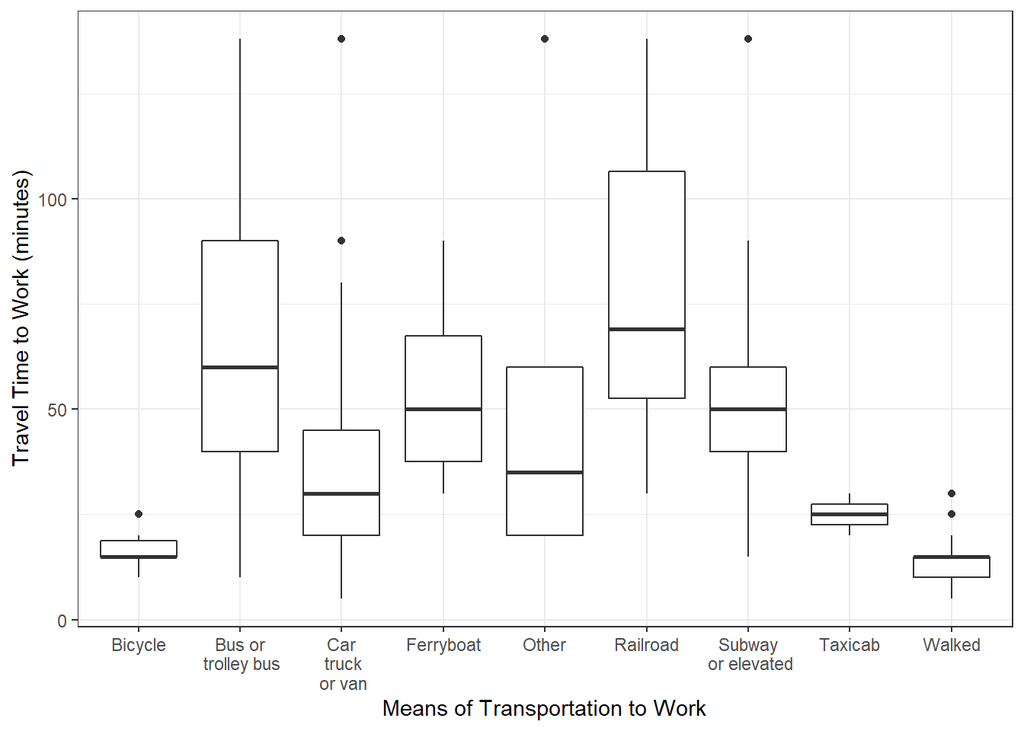

```r
ggplot(women_nyctransport2018, aes(x = JWTR_label, y = JWMNP)) +
  geom_boxplot() +
  theme_bw() +
  scale_x_discrete(name = "Means of Transportation to Work",
                  labels = c("Bicycle",
                                  "Bus or\n trolley bus",
                                  "Car\n truck\n or van",
                                  "Ferryboat",
                                  "Other",
                                  "Railroad",
                                  "Subway\n or elevated",
                                  "Taxicab",
                                  "Walked")) +
  scale_y_continuous(name = "Travel Time to Work (minutes)")
```

The following means of transportation to work present a positive correlation between these means and travel time: bus or trolley bus and bicycle; railroad and bicycle; subway or elevated and bicycle; railroad and car, truck, or van; and subway or elevated and car, truck, or van.

The following means of transportation to work present a negative correlation between these means and travel time: car, truck, or van and bus or trolley bus; walked and bus or trolley bus; walked and car, truck, or van; walked and other method; walked and railroad; and walked and subway or elevated.

I had previously expected the bicycle and walking to have a strong positive correlation with travel times, based on personal experience of using all of these methods of transportation at some point as my commute to work.

### Income and Means of Transportation

```r
anova3 <- aov(PINCP ~ JWTR_label, data = women_nyctransport2018)

summary(anova3)
```

```
##              Df    Sum Sq   Mean Sq F value   Pr(>F)
## JWTR_label    8 5.387e+11 6.734e+10   10.98 1.15e-13 ***
## Residuals   314 1.926e+12 6.134e+09
## ---
## Signif. codes:  0 '***' 0.001 '**' 0.01 '*' 0.05 '.' 0.1 ' ' 1
```

```r
differences3 <- TukeyHSD(anova3)

as_tibble(cbind(pair = row.names(differences3$JWTR_label),
                differences3$JWTR_label))
```

```
## # A tibble: 36 x 5
##    pair                     diff         lwr          upr         `p adj`
##    <chr>                    <chr>        <chr>        <chr>       <chr>
##  1 Bus or trolley bus-Bicy~ -4438.28828~ -112108.488~ 103231.911~ 0.99999999761~
##  2 Car, truck, or van-Bicy~ 15889.50617~ -87619.7696~ 119398.782~ 0.99992612082~
##  3 Ferryboat-Bicycle        370885.8333~ 212967.6432~ 528804.023~ 6.90888457555~
##  4 Other method-Bicycle     14323.33333~ -133817.060~ 162463.726~ 0.99999794794~
##  5 Railroad-Bicycle         27041.04761~ -109067.315~ 163149.410~ 0.99948772037~
##  6 Subway or elevated-Bicy~ 25605.30701~ -76223.0890~ 127433.703~ 0.99720119029~
##  7 Taxicab-Bicycle          -10383.3333~ -183374.043~ 162607.376~ 0.99999995257~
##  8 Walked-Bicycle           -1116.66666~ -111174.914~ 108941.581~ 1
##  9 Car, truck, or van-Bus ~ 20327.79446~ -28216.1889~ 68871.7778~ 0.92849407215~
## 10 Ferryboat-Bus or trolle~ 375324.1216~ 246558.8200~ 504089.423~ 1.10567111022~
## # ... with 26 more rows
```

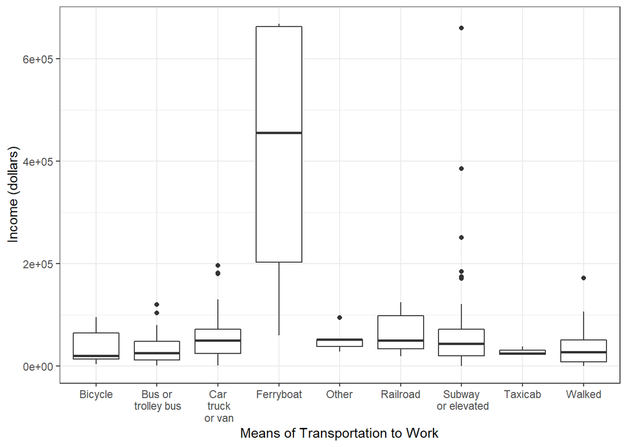

```r
ggplot(women_nyctransport2018, aes(x = JWTR_label, y = PINCP)) +
  geom_boxplot() +
  theme_bw() +
  scale_x_discrete(name = "Means of Transportation to Work",
                  labels = c("Bicycle",
                                  "Bus or\n trolley bus",
                                  "Car\n truck\n or van",
                                  "Ferryboat",
                                  "Other",
                                  "Railroad",
                                  "Subway\n or elevated",
                                  "Taxicab",
                                  "Walked")) +
  scale_y_continuous(name = "Income (dollars)")
```

The following means of transportation to work present a positive correlation between these means and income: ferryboat and bicycle; ferryboat and bus or trolley bus; and ferryboat and car, truck, or van.

The following means of transportation to work present a negative correlation between these means and income: other method and ferryboat; subway or elevated and ferryboat; taxicab and ferryboat; and walked and ferryboat.

In order to understand what’s happening with the relationship between income and taking a ferryboat as part of one’s commute to work, I would be interested in looking at more variables, such as location and average neighborhood incomes for those locations to see why there seems to be a consistent correlation between taking the ferry and income. I am interesting in seeing if location plays a part in availability to other means of transporations, and if neighborhoods where ferryboats are only available tend to have a certain average income.

### Travel Time and Race

```r
anova4 <- aov(JWMNP ~ RAC1P_label, data = women_nyctransport2018)

summary(anova4)
```

```
##              Df Sum Sq Mean Sq F value  Pr(>F)
## RAC1P_label   4  13584    3396   4.075 0.00309 **
## Residuals   318 265000     833
## ---
## Signif. codes:  0 '***' 0.001 '**' 0.01 '*' 0.05 '.' 0.1 ' ' 1
```

```r
differences4 <- TukeyHSD(anova4)

as_tibble(cbind(pair = row.names(differences4$RAC1P_label),
                differences4$RAC1P_label))
```

```
## # A tibble: 10 x 5
##    pair                         diff        lwr          upr        `p adj`
##    <chr>                        <chr>       <chr>        <chr>      <chr>
##  1 Black or African American a~ 13.6294623~ 0.035473280~ 27.223451~ 0.049043366~
##  2 Some Other Race alone-Asian~ 6.19794721~ -10.8676738~ 23.263568~ 0.856881758~
##  3 Two or More Races-Asian alo~ 2.68279569~ -22.2943324~ 27.659923~ 0.998349770~
##  4 White alone-Asian alone      -2.4732326~ -14.5418002~ 9.5953349~ 0.980344419~
##  5 Some Other Race alone-Black~ -7.4315151~ -23.9753957~ 9.1123654~ 0.732445454~
##  6 Two or More Races-Black or ~ -10.946666~ -35.5702629~ 13.676929~ 0.739958057~
##  7 White alone-Black or Africa~ -16.102695~ -27.4214796~ -4.783910~ 0.001091628~
##  8 Two or More Races-Some Othe~ -3.5151515~ -30.2127239~ 23.182420~ 0.996349339~
##  9 White alone-Some Other Race~ -8.6711798~ -23.9863282~ 6.6439684~ 0.528583765~
## 10 White alone-Two or More Rac~ -5.1560283~ -28.9714703~ 18.659413~ 0.975926431~
```

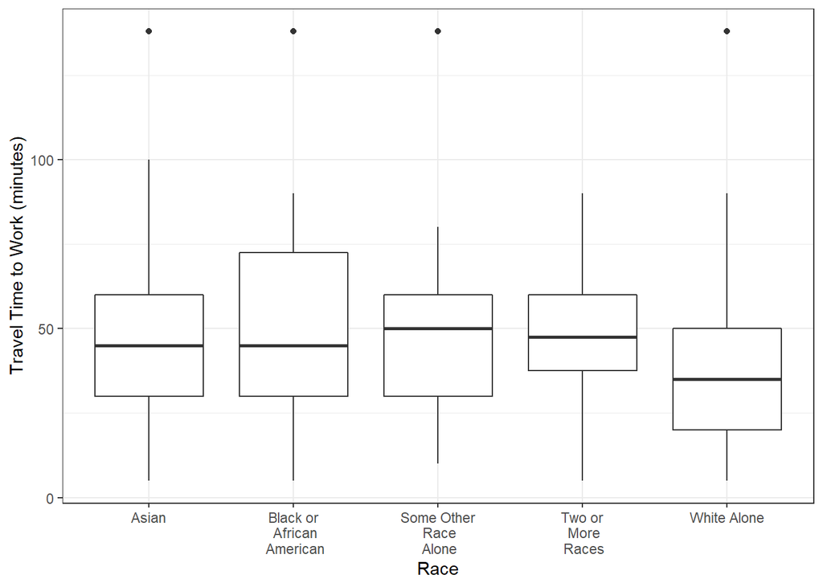

```r
ggplot(women_nyctransport2018, aes(x = RAC1P_label, y = JWMNP)) +
  geom_boxplot() +
  theme_bw() +
  scale_x_discrete(name = "Race",
                  labels = c("Asian",
                          "Black or\n African\n American",
                          "Some Other\n Race\n Alone",
                          "Two or\n More\n Races",
                          "White Alone")) +
  scale_y_continuous(name = "Travel Time to Work (minutes)")
```

The following races present a positive correlation between these race categories and travel time to work: Black or African American alone and Asian alone.

The following races present a negative correlation between these race categories and travel time to work: White alone and Black or African American alone.

### Income and Race

```r
anova5 <- aov(PINCP ~ RAC1P_label, data = women_nyctransport2018)

summary(anova5)
```

```
##              Df    Sum Sq   Mean Sq F value  Pr(>F)
## RAC1P_label   4 1.292e+11 3.230e+10   4.397 0.00179 **
## Residuals   318 2.336e+12 7.345e+09
## ---
## Signif. codes:  0 '***' 0.001 '**' 0.01 '*' 0.05 '.' 0.1 ' ' 1
```

```r
differences5 <- TukeyHSD(anova5)

as_tibble(cbind(pair = row.names(differences5$RAC1P_label),
                differences5$RAC1P_label))
```

```
## # A tibble: 10 x 5
##    pair                          diff        lwr         upr        `p adj`
##    <chr>                         <chr>       <chr>       <chr>      <chr>
##  1 Black or African American al~ 1645.63225~ -38712.801~ 42004.066~ 0.999964506~
##  2 Some Other Race alone-Asian ~ -3127.6647~ -53792.832~ 47537.503~ 0.999814950~
##  3 Two or More Races-Asian alone 12904.0322~ -61249.166~ 87057.230~ 0.989355028~
##  4 White alone-Asian alone       40918.0748~ 5088.37950~ 76747.770~ 0.016111516~
##  5 Some Other Race alone-Black ~ -4773.2969~ -53889.498~ 44342.904~ 0.998885831~
##  6 Two or More Races-Black or A~ 11258.4000~ -61845.217~ 84362.017~ 0.993318196~
##  7 White alone-Black or African~ 39272.4425~ 5668.73591~ 72876.149~ 0.012792476~
##  8 Two or More Races-Some Other~ 16031.6969~ -63229.232~ 95292.626~ 0.981277359~
##  9 White alone-Some Other Race ~ 44045.7395~ -1422.5477~ 89514.026~ 0.062750206~
## 10 White alone-Two or More Races 28014.0425~ -42690.291~ 98718.376~ 0.813188179~
```

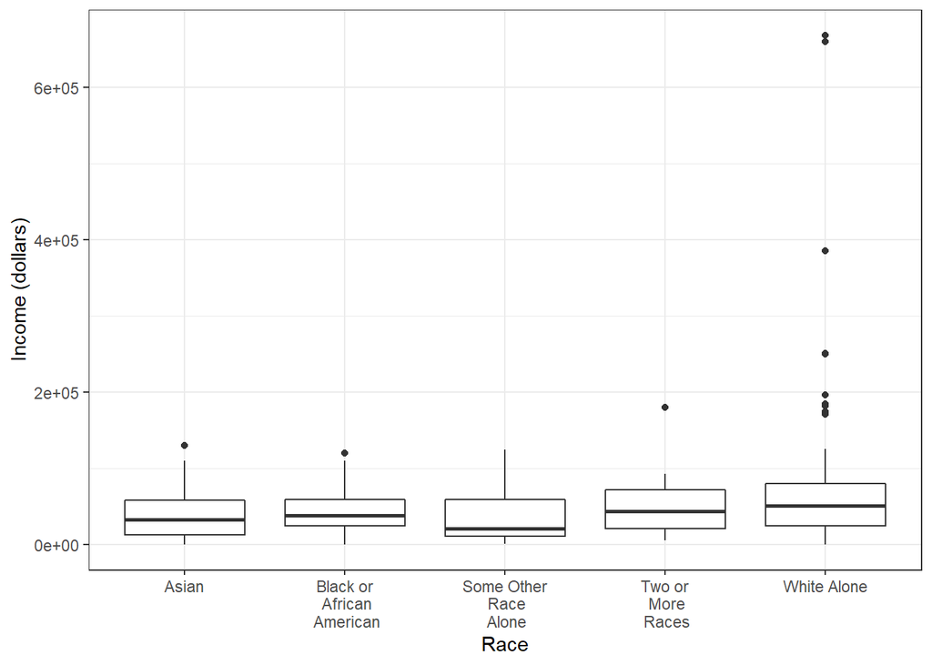

```r
ggplot(women_nyctransport2018, aes(x = RAC1P_label, y = PINCP)) +
  geom_boxplot() +
  theme_bw() +
  scale_x_discrete(name = "Race",
                  labels = c("Asian",
                          "Black or\n African\n American",
                          "Some Other\n Race\n Alone",
                          "Two or\n More\n Races",
                          "White Alone")) +
  scale_y_continuous(name = "Income (dollars)")
```

The following races present a positive correlation between these race categories and income: white alone and Asian alone; and white alone and Black or African American alone.

There are no negative correlations.

## Relationships Between Categorical Variables

### Means of Transportation to Work and Ambulatory Difficulty

```r
chi_sq1 <- chisq.test(women_nyctransport2018$JWTR_label, women_nyctransport2018$DPHY_label)
chi_sq1
```

```
##
##  Pearson's Chi-squared test
##
## data:  women_nyctransport2018$JWTR_label and women_nyctransport2018$DPHY_label
## X-squared = 16.158, df = 8, p-value = 0.04017
```

```r
chi_sq1$observed
```

```
##
##                       No Yes
##   Bicycle              6   0
##   Bus or trolley bus  36   1
##   Car, truck, or van  79   2
##   Ferryboat            3   1
##   Other method         4   1
##   Railroad             7   0
##   Subway or elevated 150   2
##   Taxicab              3   0
##   Walked              27   1
```

```r
chi_sq1$expected
```

```
##
##                              No        Yes
##   Bicycle              5.851393 0.14860681
##   Bus or trolley bus  36.083591 0.91640867
##   Car, truck, or van  78.993808 2.00619195
##   Ferryboat            3.900929 0.09907121
##   Other method         4.876161 0.12383901
##   Railroad             6.826625 0.17337461
##   Subway or elevated 148.235294 3.76470588
##   Taxicab              2.925697 0.07430341
##   Walked              27.306502 0.69349845
```

There seems to be a correlation, with a p-value of about 0.04, between ambulatory difficulty and means of transportation to work.

### Means of Transportation to Work and Race

```r
chi_sq2 <- chisq.test(women_nyctransport2018$JWTR_label, women_nyctransport2018$RAC1P_label)
chi_sq2
```

```
##
##  Pearson's Chi-squared test
##
## data:  women_nyctransport2018$JWTR_label and women_nyctransport2018$RAC1P_label
## X-squared = 53.869, df = 32, p-value = 0.009127
```

```r
chi_sq2$observed
```

```
##
##                      Asian alone Black or African American alone
##   Bicycle                      1                               0
##   Bus or trolley bus           3                              14
##   Car, truck, or van          10                              22
##   Ferryboat                    0                               1
##   Other method                 1                               3
##   Railroad                     0                               4
##   Subway or elevated          38                              26
##   Taxicab                      0                               3
##   Walked                       9                               2
##
##                      Some Other Race alone Two or More Races White alone
##   Bicycle                                0                 0           5
##   Bus or trolley bus                     7                 0          13
##   Car, truck, or van                     9                 5          35
##   Ferryboat                              0                 0           3
##   Other method                           0                 0           1
##   Railroad                               1                 0           2
##   Subway or elevated                    14                 7          67
##   Taxicab                                0                 0           0
##   Walked                                 2                 0          15
```

```r
chi_sq2$expected
```

```
##
##                      Asian alone Black or African American alone
##   Bicycle              1.1517028                       1.3931889
##   Bus or trolley bus   7.1021672                       8.5913313
##   Car, truck, or van  15.5479876                      18.8080495
##   Ferryboat            0.7678019                       0.9287926
##   Other method         0.9597523                       1.1609907
##   Railroad             1.3436533                       1.6253870
##   Subway or elevated  29.1764706                      35.2941176
##   Taxicab              0.5758514                       0.6965944
##   Walked               5.3746130                       6.5015480
##
##                      Some Other Race alone Two or More Races White alone
##   Bicycle                        0.6130031         0.2229102    2.619195
##   Bus or trolley bus             3.7801858         1.3746130   16.151703
##   Car, truck, or van             8.2755418         3.0092879   35.359133
##   Ferryboat                      0.4086687         0.1486068    1.746130
##   Other method                   0.5108359         0.1857585    2.182663
##   Railroad                       0.7151703         0.2600619    3.055728
##   Subway or elevated            15.5294118         5.6470588   66.352941
##   Taxicab                        0.3065015         0.1114551    1.309598
##   Walked                         2.8606811         1.0402477   12.222910
```

With a p-value of about 0.009, there is a correlation between race and means of transportation to work. Because the p-value is so close to 0, the correlation is weak, but a relationship does exist.

### Ambulatory Difficulty and Race

```r
chi_sq3 <- chisq.test(women_nyctransport2018$DPHY_label, women_nyctransport2018$RAC1P_label)
chi_sq3
```

```
##
##  Pearson's Chi-squared test
##
## data:  women_nyctransport2018$DPHY_label and women_nyctransport2018$RAC1P_label
## X-squared = 8.026, df = 4, p-value = 0.09063
```

```r
chi_sq3$observed
```

```
##
##       Asian alone Black or African American alone Some Other Race alone
##   No           62                              70                    32
##   Yes           0                               5                     1
##
##       Two or More Races White alone
##   No                 12         139
##   Yes                 0           2
```

```r
chi_sq3$expected
```

```
##
##       Asian alone Black or African American alone Some Other Race alone
##   No    60.464396                       73.142415            32.1826625
##   Yes    1.535604                        1.857585             0.8173375
##
##       Two or More Races White alone
##   No         11.7027864   137.50774
##   Yes         0.2972136     3.49226
```

## Assignment 3 Conclusion

There were several results which I did not expect to see when I did each of these tests. For example, I expected some variables, like travel time to work and ambulatory difficulty to have a strong correlation, yet I cannot be 95-percent confident that there even is a correlation between these two variables. Additionally, I did not expect there to be the possibility that the correlation between age and ambulatory difficulty could be nonexistent, if the p-value has a possibility of being 0. I previously held an assumption that the older people got, the more likely they may develop a mobility disability, and therefore assumed this correlation existed. This exercise has proven to me the importance of not making assumptions based on personal observations of an entire variable’s relationships, and instead to use this kind of quantitative analysis as a useful tool in reshaping the way I think about such variables. Initially, I did not think I needed to compare several variables because I did not think they had anything to do with one another, and by comparing every single variable against one another, I’ve been proven wrong.